# Ghost Trail Effect

Ghost trails, also called after images, give you feedback on your player’s movement, and show its trajectory.

They are similar to smears in animation, the process of blurring or extending characters’ limbs to exaggerate a fast motion or improve its readability. You can use ghost trails to smooth out a quick movement and make it more readable, or as a stylistic choice, as in Castlevania games on Nintendo handheld devices.

[video not shown]

In this tutorial, we use particles once again to create these trailing ghosts for 2D games.

You are going to learn to:

- Emit particles that align with the parent sprite.
- Use a gradient ramp to fade the particles.
- Make the particles move independently from their parent node.

## The Scene Setup

In our effect, we are going to use a spaceship for our character. So let’s add a *Sprite* to the scene and a *Particles2D*. Rename them as *PlayerShip* and *GhostTrail*, respectively.

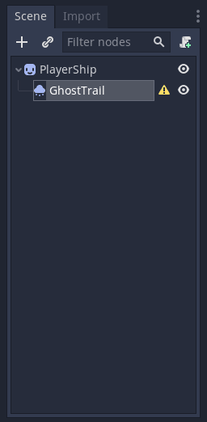

Select both nodes and drag the *topdown-player.svg*, available in the *FileSystem* dock, under the *assets* folder, and drop it on the *Texture* property. Rotate the *PlayerShip* by 90 degrees to make the tip of the spaceship face right.

[figure not shown]

We want these particles to always be behind the main sprite. For that, in the *Particles2D* turn on the *Show Behind Parent* property.

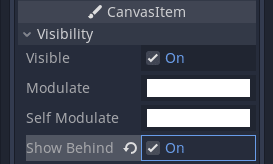

Next, in the *Material* property, create a new “ParticlesMaterial”. You should see some spaceships falling and disappearing right the way.

If you rotate the *Particles2D* around, you should notice the particles look pinned. This effect happens because the particles are drawn in local coordinates, meaning they follow the *Particles2D* node’s transform: rotation, scale, position.

[video not shown]

Let’s fix that.

## Making the particles global

Select the *Particles2D* again and search for the *Local Coordinates* property and toggle it off, with that the particles won’t suffer from changes in the *Particles2D* transform, you can test it by rotating the *Particles2D* node again.

Right below the *Local Coordinates* property, in the *Draw Order* property, left-click where it says “Index” and change it to “Lifetime” instead. Doing so makes the first particles appear behind the most recent ones. By now, the *Drawing* category should look like this:

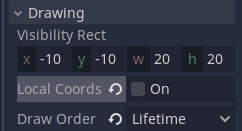

Now, in the *Material* property, right-click in the *ParticlesMaterial* and from the dropdown menu, select the “Edit” option. The Inspector should focus on the *ParticlesMaterial* resource and its properties.

Let’s also prevent the particles from falling, so they stay in place when created. Search for the *Gravity* property and make sure you set all values to zero.

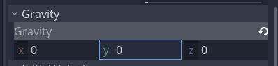

## Fixing the rotation of the particles

If you rotate the *PlayerShip* node, you should notice that the particles don’t follow its rotation.

We can use the *Align Y* property to make the particles align with the particle system’s global rotation.

To activate the align feature, go to the *Flags* category in the *ParticlesMaterial* and click the checkbox next to *Align Y*.

At this point, the particles still don’t align with the *PlayerShip*. They are flipped vertically because our particles have a velocity of 0. In the particle shader, the align property relies on each particle’s velocity to rotate it. If the velocity is 0, the particles do not turn to align with the particle system.

Find the *Initial Velocity -> Velocity* property and assign it a value of 1 to fix the issue. Also, set the *Direction > Spread* property to `0` to prevent some particles from having a slight offset.

But our ship’s texture is pointing up, so we need to update the *Direction* accordingly.

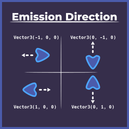

The *Direction* is a `Vector3` unit vector representing the emission direction of our particles. That’s the direction in which the *Initial Velocity* will take them, **not** the direction in which the texture is looking. The default, `Vector3(1, 0, 0)` means your particle emits to the right, that is, the positive X-axis.

In our case, we need to use 0 for the `x` and `z` values and `1` for the `y` value, which makes the particles emit downward and, thanks to the *Align Y* flag, makes the texture look up.

Now, if you move the *Particles2D* around, you should see it leave a trail of spaceships behind it. You can rotate the node ship to see the trail follow the rotation.

[video not shown]

## Animating a fade with a gradient ramp

We can use a `Gradient` resource to animate the particles’ opacity and make them fade out. In the *ParticlesMaterial*, search for the *Color Ramp* category and create a new *GradientTexture*. Click on it, and in the *Gradient* slot, create a new *Gradient*.

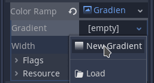

Change the color on the left corner to a semi-transparent white and the one on the right corner to a fully transparent white.

To make a color transparent, click on the color stop on the gradient, then click on the square representing the color at the right of the gradient. Doing so opens a color picker.

In the color picker, drag the “A” slider to the left to make your color more transparent.

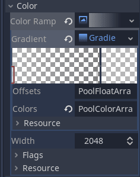

## Final tweaks

The ghost trail is ready! All that’s left is to tweak the *Amount* and *Lifetime* properties to fit your game’s feel better. To me, for the ship, an *Amount* of 8 and a *Lifetime* of 0.5 looks good.

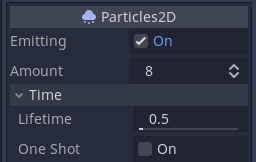

If you want to use this effect for a one-time mechanic, like dash over a fixed distance, you can toggle the *One Shot* property of the particle system. It makes the particle system emit only one cycle after setting their *Emitting* property to `true`.

## Limitations of our approach

Using a particle system as we did works for individual sprites, but if you split your character into multiple sprites that you animate in Godot, you are going to need to make some changes.

You have three alternatives to get a trail as in this tutorial. You can:

1. Use pre-rendered animations and use a single *Particles2D* node, as we did.
2. Use one *Particles2D* node with the same material for each sprite on the character. This approach works well if your character has few sprites and limbs.
3. A more advanced and technical option is to render the animated character to a dedicated viewport and use that as a texture.